# capstone_project_mobilenet_Xceptionnet_implementation

#### Import Packages

```python
import warnings
warnings.filterwarnings('ignore')
```

```python
import numpy as np
import pandas as pd
import os
import math
import cv2

from matplotlib import pyplot
import matplotlib.patches as patches

from skimage import measure
from skimage.transform import resize

import seaborn as sns
import pydicom as dcm

from sklearn import metrics
from sklearn.metrics import classification_report
```

```python
import tensorflow as tf
import tensorflow.keras.utils as pltUtil
from tensorflow.keras.utils import Sequence

from tensorflow.keras.layers import Layer, Concatenate, UpSampling2D, Conv2D, Reshape, BatchNormalization, Activation
from tensorflow.keras.models import Model

#For MobileNet
from tensorflow.keras.applications.mobilenet import MobileNet
from tensorflow.keras.applications.mobilenet import preprocess_input

#For Xception
from tensorflow.keras.applications import Xception

#For tunning of model
from tensorflow.keras.optimizers import Adam
from tensorflow.keras.callbacks import ModelCheckpoint, EarlyStopping, ReduceLROnPlateau, LearningRateScheduler
```

Setting up of Project Path

```python
#let us Set up of Project Path
data_dir = '../input/rsna-pneumonia-detection-challenge/'

train_images = data_dir + 'stage_2_train_images'
```

### Function Definitions

#### Function to load metadata from images

```python
class image_metadata():

    def __init__(self, setName, file):
        self.setName = setName
        self.file = file

    def __repr__(self):
        #a special method used to represent a class's objects as a string
        return self.imagePath()

    def imagePath(self):
        return os.path.join(self.setName, self.file)
```

```python
#function to load image metadata
def loadimagemetadata(dataSetName):
    imageMetadata = []
    for f in os.listdir(dataSetName):
        ext = os.path.splitext(f)[1]
        if ext == '.dcm':
            imageMetadata.append(image_metadata(dataSetName, f))
    return np.array(imageMetadata)
```

```python
#function to load image and patientId
def loadImage(path):

    img = dcm.dcmread(path)
    return img

def getImgId(imgPath):
    return str(imgPath).split(".dcm")[0].split("/")[4]
```

Getting Metadata Information

```python
#Getting the Metadata Information
trainingSetImageMetadata = loadimagemetadata(train_images)
print('Shape of training set image metadata: ', trainingSetImageMetadata.shape)
print("Sample image path: ", trainingSetImageMetadata[0])
```

```
Shape of training set image metadata:  (26684,)
Sample image path:  ../input/rsna-pneumonia-detection-challenge/stage_2_train_images/c3b05294-29be-46e4-8a51-96fd211e4ca5.dcm
```

# Loading a sample Image

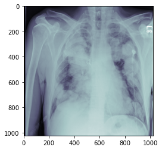

```python
imgIndex = 24
imgPath = trainingSetImageMetadata[imgIndex]
imgPath = imgPath.imagePath()
imgData = loadImage(imgPath)

pyplot.imshow(imgData.pixel_array, cmap = pyplot.cm.bone)
```

#### Preparing Dataset with patient Id and respective image paths

```python
trainSetImageMetadata_df = pd.DataFrame(trainingSetImageMetadata, columns = ['Path'])

imageIdpaths = pd.DataFrame(columns = ['patientId', 'imgPath'])
imageIdpaths['patientId'] = trainSetImageMetadata_df['Path'].apply(getImgId)
imageIdpaths['imgPath'] = trainSetImageMetadata_df['Path']

print("Shape of the concerned dataset: ", imageIdpaths.shape)
print('The dataset looks as:\n')
imageIdpaths.head()
```

```
Shape of the concerned dataset:  (26684, 2)
The dataset looks as:
```

|  | patientId | imgPath |
| --- | --- | --- |
| 0 | c3b05294-29be-46e4-8a51-96fd211e4ca5 | ../input/rsna-pneumonia-detection-challenge/st... |
| 1 | 6a6ed2c5-d179-4c19-aac7-0d70eb87e024 | ../input/rsna-pneumonia-detection-challenge/st... |
| 2 | 06550cfd-e9d5-415e-bae9-3146329ed9e6 | ../input/rsna-pneumonia-detection-challenge/st... |
| 3 | ef9eee29-6bdd-41da-ae40-9473592a9d5c | ../input/rsna-pneumonia-detection-challenge/st... |
| 4 | c5dfc1a7-4669-42ce-af9f-62c3d8322049 | ../input/rsna-pneumonia-detection-challenge/st... |

Thus, we have a dataframe here with two columns: **patientId** and **imgPath**. These columns contains the patientid and the location where the images are stored.

## Reading CSV Files

```python
detailclass_df = pd.read_csv('../input/rsna-pneumonia-detection-challenge/stage_2_detailed_class_info.csv')
trainlabels_df = pd.read_csv('../input/rsna-pneumonia-detection-challenge/stage_2_train_labels.csv')
```

```python
print('The detailed class dataframe has {} rows and {} columns and looks like:'.format(detailclass_df.shape[0], detailclass_df.shape[1]))
detailclass_df.head()
```

```
The detailed class dataframe has 30227 rows and 2 columns and looks like:
```

|  | patientId | class |
| --- | --- | --- |
| 0 | 0004cfab-14fd-4e49-80ba-63a80b6bddd6 | No Lung Opacity / Not Normal |
| 1 | 00313ee0-9eaa-42f4-b0ab-c148ed3241cd | No Lung Opacity / Not Normal |
| 2 | 00322d4d-1c29-4943-afc9-b6754be640eb | No Lung Opacity / Not Normal |
| 3 | 003d8fa0-6bf1-40ed-b54c-ac657f8495c5 | Normal |
| 4 | 00436515-870c-4b36-a041-de91049b9ab4 | Lung Opacity |

```python
print('The training label dataframe has {} rows and {} columns and looks like:'.format(trainlabels_df.shape[0], trainlabels_df.shape[1]))
trainlabels_df.head()
```

```
The training label dataframe has 30227 rows and 6 columns and looks like:
```

|  | patientId | x | y | width | height | Target |
| --- | --- | --- | --- | --- | --- | --- |
| 0 | 0004cfab-14fd-4e49-80ba-63a80b6bddd6 | NaN | NaN | NaN | NaN | 0 |
| 1 | 00313ee0-9eaa-42f4-b0ab-c148ed3241cd | NaN | NaN | NaN | NaN | 0 |
| 2 | 00322d4d-1c29-4943-afc9-b6754be640eb | NaN | NaN | NaN | NaN | 0 |
| 3 | 003d8fa0-6bf1-40ed-b54c-ac657f8495c5 | NaN | NaN | NaN | NaN | 0 |
| 4 | 00436515-870c-4b36-a041-de91049b9ab4 | 264.0 | 152.0 | 213.0 | 379.0 | 1 |

```python
#sorting both the datasets based on patientId
trainlabels_df.sort_values('patientId', inplace = True)
detailclass_df.sort_values('patientId', inplace = True)

#concatenating the data
merge_data_df = pd.concat([trainlabels_df, detailclass_df['class']], axis = 1, sort = False)
print('The merged dataset has {} rows and {} columns and looks like:'.format(merge_data_df.shape[0], merge_data_df.shape[1]))
merge_data_df.head()
```

```
The merged dataset has 30227 rows and 7 columns and looks like:
```

|  | patientId | x | y | width | height | Target | class |
| --- | --- | --- | --- | --- | --- | --- | --- |
| 0 | 0004cfab-14fd-4e49-80ba-63a80b6bddd6 | NaN | NaN | NaN | NaN | 0 | No Lung Opacity / Not Normal |
| 28989 | 000924cf-0f8d-42bd-9158-1af53881a557 | NaN | NaN | NaN | NaN | 0 | Normal |
| 28990 | 000db696-cf54-4385-b10b-6b16fbb3f985 | 316.0 | 318.0 | 170.0 | 478.0 | 1 | Lung Opacity |
| 28991 | 000db696-cf54-4385-b10b-6b16fbb3f985 | 660.0 | 375.0 | 146.0 | 402.0 | 1 | Lung Opacity |
| 28992 | 000fe35a-2649-43d4-b027-e67796d412e0 | 570.0 | 282.0 | 269.0 | 409.0 | 1 | Lung Opacity |

```python
#convert the dataset into two classes only:
merge_data_df['class'].replace('No Lung Opacity / Not Normal', 'Normal', inplace = True)
print('The merge dataset now looks like:')
merge_data_df.head()
```

```
The merge dataset now looks like:
```

|  | patientId | x | y | width | height | Target | class |
| --- | --- | --- | --- | --- | --- | --- | --- |
| 0 | 0004cfab-14fd-4e49-80ba-63a80b6bddd6 | NaN | NaN | NaN | NaN | 0 | Normal |
| 28989 | 000924cf-0f8d-42bd-9158-1af53881a557 | NaN | NaN | NaN | NaN | 0 | Normal |
| 28990 | 000db696-cf54-4385-b10b-6b16fbb3f985 | 316.0 | 318.0 | 170.0 | 478.0 | 1 | Lung Opacity |
| 28991 | 000db696-cf54-4385-b10b-6b16fbb3f985 | 660.0 | 375.0 | 146.0 | 402.0 | 1 | Lung Opacity |
| 28992 | 000fe35a-2649-43d4-b027-e67796d412e0 | 570.0 | 282.0 | 269.0 | 409.0 | 1 | Lung Opacity |

#### Splitting of the dataset

now let us split the merge_data_df to have three different datasets: train, validation and test.

```python
train_mergedata = merge_data_df[0:15000]
validate_mergedata = merge_data_df[15000:25000]
test_mergedata = merge_data_df[25000:30227]

print('Shape of training data: ', train_mergedata.shape)
print('Shape of validation data: ', validate_mergedata.shape)
print('Shape of test data: ', test_mergedata.shape)
```

```
Shape of training data:  (15000, 7)
Shape of validation data:  (10000, 7)
Shape of test data:  (5227, 7)
```

And now we have a training set with 15000 entries, validation set with 10000 entries and 5227 with test dataset.

```python
#setting all NaN values to 0 in both the data sets
#x, y, width and hight values as zero(0) means no bounding box.
train_mergedata.fillna(0, inplace = True)
print('The training data now looks as: \n')
train_mergedata.head()
```

```
The training data now looks as:
```

|  | patientId | x | y | width | height | Target | class |
| --- | --- | --- | --- | --- | --- | --- | --- |
| 0 | 0004cfab-14fd-4e49-80ba-63a80b6bddd6 | 0.0 | 0.0 | 0.0 | 0.0 | 0 | Normal |
| 28989 | 000924cf-0f8d-42bd-9158-1af53881a557 | 0.0 | 0.0 | 0.0 | 0.0 | 0 | Normal |
| 28990 | 000db696-cf54-4385-b10b-6b16fbb3f985 | 316.0 | 318.0 | 170.0 | 478.0 | 1 | Lung Opacity |
| 28991 | 000db696-cf54-4385-b10b-6b16fbb3f985 | 660.0 | 375.0 | 146.0 | 402.0 | 1 | Lung Opacity |
| 28992 | 000fe35a-2649-43d4-b027-e67796d412e0 | 570.0 | 282.0 | 269.0 | 409.0 | 1 | Lung Opacity |

```python
validate_mergedata.fillna(0, inplace = True)
print('\nThe validation data now looks as:\n')
validate_mergedata.head()
```

```
The validation data now looks as:
```

|  | patientId | x | y | width | height | Target | class |
| --- | --- | --- | --- | --- | --- | --- | --- |
| 13841 | 8a546535-613f-49b1-897c-a0933c53cb84 | 97.0 | 157.0 | 228.0 | 583.0 | 1 | Lung Opacity |
| 13842 | 8a546535-613f-49b1-897c-a0933c53cb84 | 446.0 | 175.0 | 247.0 | 644.0 | 1 | Lung Opacity |
| 13843 | 8a56a448-1214-4d0d-a6b2-d5e285d8742f | 0.0 | 0.0 | 0.0 | 0.0 | 0 | Normal |
| 13844 | 8a57180c-4321-475a-8448-8db41045c604 | 0.0 | 0.0 | 0.0 | 0.0 | 0 | Normal |
| 13845 | 8a58d9e2-9cf1-405b-8e7e-102117a8200d | 0.0 | 0.0 | 0.0 | 0.0 | 0 | Normal |

```python
test_mergedata.fillna(0, inplace = True)
print('The test data now looks as:')
test_mergedata.head()
```

```
The test data now looks as:
```

|  | patientId | x | y | width | height | Target | class |
| --- | --- | --- | --- | --- | --- | --- | --- |
| 23762 | d5d0be71-4579-411a-9218-0f45a80df505 | 0.0 | 0.0 | 0.0 | 0.0 | 0 | Normal |
| 23763 | d5d46405-ff85-46fa-9c3b-2c21ad366f76 | 709.0 | 534.0 | 96.0 | 65.0 | 1 | Lung Opacity |
| 23764 | d5d6f7e3-5143-4955-901e-cad92024fee0 | 0.0 | 0.0 | 0.0 | 0.0 | 0 | Normal |
| 23765 | d5d7c95e-0682-4b93-bf0b-5dff2fa91a92 | 215.0 | 221.0 | 188.0 | 253.0 | 1 | Lung Opacity |
| 23766 | d5d7c95e-0682-4b93-bf0b-5dff2fa91a92 | 594.0 | 256.0 | 230.0 | 176.0 | 1 | Lung Opacity |

```python
#Splitting of the dataset containing the image Paths into three: train, validation and test.
print("Number of unique patients in training dataset: ", train_mergedata["patientId"].nunique())
print("Number of unique patients in validation dataset: ", validate_mergedata["patientId"].nunique())
print("Number of unique patients in test dataset: ", test_mergedata["patientId"].nunique())
```

```
Number of unique patients in training dataset:  13163
Number of unique patients in validation dataset:  8601
Number of unique patients in test dataset:  4920
```

```python
imageIdpaths.sort_values('patientId', inplace = True)

train_imageIdpaths = imageIdpaths[0:13163]
validate_imageIdpaths = imageIdpaths[13163:21764]
test_imageIdpaths = imageIdpaths[21764:26684]

print('Shape of training dataframe having patientId and image paths: ', train_imageIdpaths.shape)
print('Shape of validation dataframe having patientId and image paths: ', validate_imageIdpaths.shape)
print('Shape of test dataframe having patientId and image paths: ', test_imageIdpaths.shape)
```

```
Shape of training dataframe having patientId and image paths:  (13163, 2)
Shape of validation dataframe having patientId and image paths:  (8601, 2)
Shape of test dataframe having patientId and image paths:  (4920, 2)
```

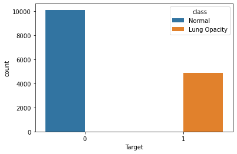

```python
sns.countplot(x = 'Target', hue = 'class', data = train_mergedata)
```

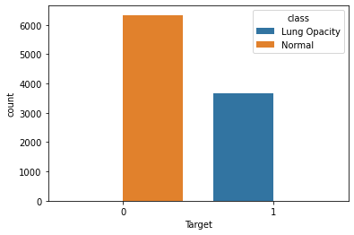

```python
sns.countplot(x = 'Target', hue = 'class', data = validate_mergedata)
```

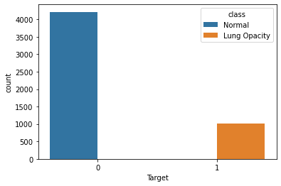

```python
sns.countplot(x = 'Target', hue = 'class', data = test_mergedata)
```

```python
# define iou or jaccard loss function
def iou_loss(y_true, y_pred):
    """
    Arguments:
        y_true -- ground truth mask
        y_pred -- predicted mask
    """

    y_true = tf.reshape(y_true, [-1])
    y_pred = tf.reshape(y_pred, [-1])
    intersection = tf.reduce_sum(y_true * y_pred)
    score = (intersection + 1.) / (tf.reduce_sum(y_true) + tf.reduce_sum(y_pred) - intersection + 1.)
    return 1 - score

# mean iou as a metric
def mean_iou(y_true, y_pred):
    """
    Arguments:
        y_true -- ground truth mask
        y_pred -- predicted mask
    """

    y_pred = tf.round(y_pred)
    intersect = tf.reduce_sum(y_true * y_pred, axis = [1])
    union = tf.reduce_sum(y_true, axis = [1]) + tf.reduce_sum(y_pred, axis = [1])
    smooth = tf.ones(tf.shape(intersect))
    return tf.reduce_mean((intersect + smooth) / (union - intersect + smooth))
```

```python
#Function to obtain Intersection Over Union (IoU) ratio from Ground Truth and Predicted Box Coordinates
def iouFromCoords(boxA, boxB) :
    """
    Arguments:
        boxA -- ground truth mask
        boxB -- predicted mask
    """

    # determine the (x, y)-coordinates of the intersection rectangle
    xA = max(boxA[0], boxB[0])
    yA = max(boxA[1], boxB[1])
    xB = min(boxA[2], boxB[2])
    yB = min(boxA[3], boxB[3])

    # compute the area of intersection rectangle
    intersectionArea = abs(max((xB - xA, 0)) * max((yB - yA), 0))
    if intersectionArea == 0:
        return 0

    # compute the area of both the prediction and ground-truth rectangles
    boxAArea = abs((boxA[2] - boxA[0]) * (boxA[3] - boxA[1]))
    boxBArea = abs((boxB[2] - boxB[0]) * (boxB[3] - boxB[1]))

    # compute the intersection over union
    iou = intersectionArea / float(boxAArea + boxBArea - intersectionArea)

    # return the intersection over union value
    return iou
```

## Function for display the image with an imposing mask

```python
def showMaskedImage(_imageSet, _maskSet, _index) :
    """
    Arguments:
        _imageSet -- set of images
        _maskSet -- set of masks
        _index -- index of a set/collection
    """

    maskImage = _imageSet[_index]

    maskImage[:,:,0] = _maskSet[_index] * _imageSet[_index][:,:,0]
    maskImage[:,:,1] = _maskSet[_index] * _imageSet[_index][:,:,1]
    maskImage[:,:,2] = _maskSet[_index] * _imageSet[_index][:,:,2]

    pyplot.imshow(maskImage[:,:,0], cmap=pyplot.cm.bone)
```

```python
image_size = 224
img_width = 1024
img_height = 1024

train_batch_size = 10
test_batch_size = 10
```

```python
### A class is being defined to get data batch for training the model
```

```python
#Generator class to get data batch for training the model. It extends the Sequence class
class UNetTrainGenerator(Sequence):

    def __init__(self, _imageIdPaths, _mergedata):
        self.pids = _mergedata['patientId'].to_numpy()
        self.imgIdPaths = _imageIdPaths
        self.coords = _mergedata[["x", "y", "width", "height"]].to_numpy()
        self.coords = self.coords * image_size / img_width

    def __len__(self):
        return math.ceil(len(self.coords) / train_batch_size)

    def __getitem__(self, idx):
        batch_coords = self.coords[idx * train_batch_size:(idx + 1) * train_batch_size] #image coords
        batch_pids = self.pids[idx * train_batch_size:(idx + 1) * train_batch_size] #image pids

        batch_images = np.zeros((len(batch_pids), image_size, image_size, 3), dtype = np.float32)
        batch_masks = np.zeros((len(batch_pids), image_size, image_size))

        for _indx, _pid in enumerate(batch_pids):
            _path = self.imgIdPaths[self.imgIdPaths["patientId"] == _pid]['imgPath'].array[0]
            _imgData = loadImage(str(_path))
            img = _imgData.pixel_array

            resized_image = cv2.resize(img, (image_size, image_size), interpolation = cv2.INTER_AREA)

            #preprocess image
            batch_images[_indx][:,:,0] = preprocess_input(np.array(resized_image[:,:], dtype = np.float32))
            batch_images[_indx][:,:,1] = preprocess_input(np.array(resized_image[:,:], dtype = np.float32))
            batch_images[_indx][:,:,2] = preprocess_input(np.array(resized_image[:,:], dtype = np.float32))

            x = int(batch_coords[_indx, 0])
            y = int(batch_coords[_indx, 1])
            width = int(batch_coords[_indx, 2])
            height = int(batch_coords[_indx, 3])

            batch_masks[_indx][y:y+height, x:x+height] = 1

        return batch_images, batch_masks
```

This class **UNetTrainGenerator** will help to load the training and validation data into the memory.

```python
#Generator to Predict the model
class UNetTestGenerator(Sequence):

    def __init__(self, _imageIdPaths, _mergedata):
        self.pids = _mergedata["patientId"].to_numpy()
        self.imgIdPaths = _imageIdPaths
        self.coords = _mergedata[["x", "y", "width", "height", "Target"]].to_numpy()
        self.classes = _mergedata["class"]
        # Resize Bounding box
        self.coordsOrig = self.coords
        self.coords = self.coords * image_size / img_width

    def __len__(self):
        # Returns total number of batches
        return math.ceil(len(self.coords) / test_batch_size)


    def __getitem__(self, idx):
        batch_coords = self.coords[idx * test_batch_size:(idx + 1) * test_batch_size]
        batch_coordsOrig = self.coordsOrig[idx * test_batch_size:(idx + 1) * test_batch_size]
        batch_pids = self.pids[idx * test_batch_size:(idx + 1) * test_batch_size]
        batch_classes = self.classes[idx * test_batch_size:(idx + 1) * test_batch_size]

        batch_images = np.zeros((len(batch_pids), image_size, image_size, 3), dtype=np.float32)
        batch_masks = np.zeros((len(batch_pids), image_size, image_size))
        for _indx, _pid in enumerate(batch_pids):
            _path = self.imgIdPaths[self.imgIdPaths["patientId"] == _pid]["imgPath"].array[0]
            _imgData = loadImage(str(_path))
            img = _imgData.pixel_array

            # Resize image
            resized_img = cv2.resize(img, (image_size, image_size), interpolation=cv2.INTER_AREA)
            # preprocess image for the batch
            batch_images[_indx][:,:,0] = preprocess_input(np.array(resized_img[:,:], dtype=np.float32))
            batch_images[_indx][:,:,1] = preprocess_input(np.array(resized_img[:,:], dtype=np.float32))
            batch_images[_indx][:,:,2] = preprocess_input(np.array(resized_img[:,:], dtype=np.float32))

            x = int(batch_coords[_indx, 0])
            y = int(batch_coords[_indx, 1])
            width = int(batch_coords[_indx, 2])
            height = int(batch_coords[_indx, 3])
            target = int(batch_coords[_indx, 4])

            batch_coords[_indx, 0] = x
            batch_coords[_indx, 1] = y
            batch_coords[_indx, 2] = width
            batch_coords[_indx, 3] = height
            batch_coords[_indx, 4] = target

            batch_masks[_indx][y:y+height, x:x+width] = 1

        # Returns images, ground truth masks, patientIds, resized-coordinates, class targets and ground truth coordinates/lables.
        return batch_images, batch_masks, batch_pids, batch_coords, batch_classes, batch_coordsOrig
```

```python
#Function to create UNet architecture with MobileNet
def create_UNetModel(trainable=True):
    """
    Arguments:
        trainable: Flag to make layers trainable. Default value is 'True'.
    """
    # Get all layers with 'imagenet' weights
    model = MobileNet(input_shape = (image_size, image_size, 3), include_top=False,
                      alpha = 1.0, weights="imagenet")
    # Top layer is last layer of the model

    # Make all layers trainable
    for layer in model.layers:
        layer.trainable = trainable

    # Add all the UNET layers here
    convLayer_112by112 = model.get_layer("conv_pw_1_relu").output
    convLayer_56by56 = model.get_layer("conv_pw_3_relu").output
    convLayer_28by28 = model.get_layer("conv_pw_5_relu").output
    convLayer_14by14 = model.get_layer("conv_pw_11_relu").output
    convLayer_7by7 = model.get_layer("conv_pw_13_relu").output
    # The last layer of mobilenet model is of dimensions (7x7x1024)
    # Steps to upsample from 7x7 to 14x14..upto 224x224 to form UNET
    x = Concatenate()([UpSampling2D()(convLayer_7by7), convLayer_14by14])
    x = Concatenate()([UpSampling2D()(x), convLayer_28by28])
    x = Concatenate()([UpSampling2D()(x), convLayer_56by56])
    x = Concatenate()([UpSampling2D()(x), convLayer_112by112])
    x = UpSampling2D(name="unet_last")(x) # upsample to 224x224

    # Add classification layer
    x = Conv2D(1, kernel_size=1, activation="sigmoid", name="masks")(x)
    x = Reshape((image_size, image_size))(x)

    return Model(inputs=model.input, outputs=x)
```

```python
#Xception net model creation
def create_UNetModel_Xception(trainable=True):
    """
    Arguments:
        trainable: Flag to make layers trainable. Default value is 'True'.
    """
    # Get all layers with 'imagenet' weights
    model = Xception(input_shape = (image_size, image_size, 3), include_top=False,
                       weights="imagenet")
    # Top layer is last layer of the model

    # Make all layers trainable
    for layer in model.layers:
        layer.trainable = trainable

    # Add all the UNET layers here
    convLayer_111by111 = model.get_layer("block1_conv1_act").output
    convLayer_55by55 = model.get_layer("block3_sepconv2_act").output
    convLayer_28by28 = model.get_layer("block4_sepconv2_act").output
    convLayer_14by14 = model.get_layer("block13_sepconv2_act").output
    convLayer_7by7 = model.get_layer("block14_sepconv2_act").output
    # The last layer of mobilenet model is of dimensions (7x7x1024)
    # Steps to upsample from 7x7 to 14x14..upto 224x224 to form UNET
    x = Concatenate()([UpSampling2D()(convLayer_7by7), convLayer_14by14])
    x = Concatenate()([UpSampling2D()(x), convLayer_28by28])
    #x = Concatenate()([UpSampling2D()(x), convLayer_55by55])
    #x = Concatenate()([UpSampling2D()(x), convLayer_111by111])
    x = UpSampling2D(name="unet_last")(x) # upsample to 224x224

    # Add classification layer
    x = Conv2D(1, kernel_size=1, activation="sigmoid", name="masks")(x)
    x = Reshape((image_size, image_size))(x)

    return Model(inputs=model.input, outputs=x)
```

## Function to create Confusion Matrix and Classification Report

```python
def showConfusionMatrix(IOU_report) :
    """
    Arguments:
        IOU_report: dataframe having target and prediction columns.
    """

    IOU_report.fillna(0, inplace=True)

    # Get Targets and Predictions
    y_IOU_test = IOU_report["Target"]
    y_IOU_predicted = IOU_report["predTarget"]
    print("Predictions in terms of IOU :\n")
    print("Confusion Matrix:\n", metrics.confusion_matrix(y_IOU_test, y_IOU_predicted))
    print("\nClassification Report:\n", metrics.classification_report(y_IOU_test, y_IOU_predicted))
```

the useful function to predict test data set and save the submission report into a csv file

```python
def predictBatches(_test_mergedata, _test_imageIdpaths, _UNetModel) :
    """
    Arguments:
        _test_mergedata: test set dataframe having patientId, bounding box coordinates, target and class
        _test_imageIdpaths: test set dataframe having patientId and image paths to load image
        _UNetModel: UNet model with trainined weights used for predicting test data
    """

    print('Number of Test Samples:', _test_mergedata["patientId"].nunique())

    # create test generator instance
    testUNetDataGen = UNetTestGenerator(_test_imageIdpaths, _test_mergedata)

    # create submission dafa frame with column names
    submissionDF = pd.DataFrame(columns=['patientId', 'x', 'y', 'width', 'height', 'Target', 'class', 'x_pred', 'y_pred', 'width_pred',
                                         'height_pred', 'predTarget', 'iou', 'class_pred'])
    dfIndex = 0
    iouThreshold = 0.3 # IoU above 30%

    # loop through testset
    # for batches from testUNetDataGen
    print("Predicting Batches ", end='')
    for batchImages, gtBatchMasks, batchPids, batchCoords, batchClasses, batchCoordsOrig in testUNetDataGen:

        # predict batch of images
        batchPreds = _UNetModel.predict(batchImages)

        prevPid = ""
        # loop through batch
        for pred, gtMask, pid, coords, gtClass, coordsOrig in zip(batchPreds, gtBatchMasks, batchPids, batchCoords, batchClasses, batchCoordsOrig):   #for (224, 224)

            if prevPid != pid :
                prevPid = pid

                # resize predicted mask
                pred = resize(pred, (1024, 1024), mode='reflect')   #for (1024, 1024)
                # recompute coords for resized pred
                coords = coordsOrig   #for (1024, 1024)

                # threshold predicted mask
                strongPred = pred[:, :] > 0.5

                # apply connected components
                strongPred = measure.label(strongPred)

                loopIndx = 0
                # collect all reagions for the prediction
                iouCoordsDF = pd.DataFrame(columns=['iou', 'x', 'y', 'width', 'height'])
                for region in measure.regionprops(strongPred) :
                    # retrieve x, y, height and width
                    y, x, y2, x2 = region.bbox
                    height = y2 - y
                    width = x2 - x
                    # Get IOUs
                    coordsXYs = np.array([coords[0], coords[1], coords[2]+coords[0], coords[3]+coords[1]])
                    regionXYs = np.array([x, y, x2, y2])
                    IOU = iouFromCoords(coordsXYs, regionXYs)
                    iouCoordsRow = [IOU, x, y, width, height]
                    iouCoordsDF.loc[loopIndx] = iouCoordsRow
                    loopIndx = loopIndx + 1

                GTDFRow = [pid, coords[0], coords[1], coords[2], coords[3], coords[4], gtClass] # ground truth data
                prevGTDFRow = []
                # Get top 2 predictions based on IOU
                iouCoordsDF.sort_values("iou", ascending=False, inplace=True)
                predIOUCoordCount = 0
                # If predictions exist
                if len(iouCoordsDF) > 0 :
                    for predIOUCoordIdx in (0, len(iouCoordsDF)-1) :
                        if iouCoordsDF.loc[predIOUCoordIdx]["iou"] > iouThreshold :
                            # add row with ground truth and prediction values to data frame
                            submissionDFRow = [pid, coords[0], coords[1], coords[2], coords[3], coords[4],
                                               gtClass, int(iouCoordsDF.loc[predIOUCoordIdx]["x"]), int(iouCoordsDF.loc[predIOUCoordIdx]["y"]),
                                               int(iouCoordsDF.loc[predIOUCoordIdx]["width"]), int(iouCoordsDF.loc[predIOUCoordIdx]["height"]),
                                               1, iouCoordsDF.loc[predIOUCoordIdx]["iou"], "Lung Opacity"]
                            if predIOUCoordCount < 2 :
                                if GTDFRow != prevGTDFRow :
                                    submissionDF.loc[dfIndex] = submissionDFRow
                                    dfIndex = dfIndex + 1
                                    predIOUCoordCount = predIOUCoordCount + 1
                                    prevGTDFRow = GTDFRow
                            else :
                                break;
                        else : # Normal if IOU below threshold
                            # add row with ground truth and prediction values to data frame
                            if GTDFRow != prevGTDFRow :
                                submissionDFRow = [pid, coords[0], coords[1], coords[2], coords[3], coords[4],
                                                   gtClass, 0, 0, 0, 0, 0, iouCoordsDF.loc[predIOUCoordIdx]["iou"], "Normal"]
                                submissionDF.loc[dfIndex] = submissionDFRow
                                dfIndex = dfIndex + 1
                                prevGTDFRow = GTDFRow
                                break;
                else : # else of If predictions exist. Normal if no predictions
                    # add row with ground truth and prediction values to data frame
                    submissionDFRow = [pid, coords[0], coords[1], coords[2], coords[3], coords[4],
                                       gtClass, 0, 0, 0, 0, 0, 'NA', "Normal"]
                    submissionDF.loc[dfIndex] = submissionDFRow
                    dfIndex = dfIndex + 1

    # save dictionary as csv file
    submissionDF.to_csv('submission.csv', index=False)
    print("Prediction Complete!")

    test_y = submissionDF["Target"]
    predicted_y = submissionDF["predTarget"]

    return test_y.apply(int), predicted_y.apply(int)
```

```python
##Function to visualize predictions by displaying the ground truth and predicted bounding box
```

```python
def visualizePredictions(_predReportDF, _topNum) :
    """
    Arguments:
        _predReportDF: dataframe having patientId, IoUs, target and prediction coordinate columns.
        _topNum -- number indicating the count of top predictions to be visualized.
    """
    # Sort on IOU to get higher IOUs on top
    _predReportDF.sort_values("iou", ascending=False, inplace=True)
    # Get patientIds
    topPids = _predReportDF["patientId"].head(_topNum)
    topPidsAry = np.array(topPids)
    # Get IOUs
    topIOUs = _predReportDF["iou"].head(_topNum)
    topIOUsAry = np.array(topIOUs)

    # To get ground truth images for top IOU scored pids
    imageCollc = np.zeros((_topNum, img_width, img_height), np.float32)

    # Get ground truth coordinates for top IOU scored rows and prepare masks
    gtCoordCollc = _predReportDF[["x", "y", "width", "height"]].to_numpy()
    # To get ground truth masks
    gtMaskCollc  = np.zeros((_topNum, img_width, img_height), np.int)

    # Get ground truth coordinates for top IOU scored rows and prepare masks
    predCoordCollc = _predReportDF[["x_pred", "y_pred", "width_pred", "height_pred"]].to_numpy()  # (1024, 1024)
    # To get ground truth masks
    predMaskCollc  = np.zeros((_topNum, img_width, img_height), np.int)

    # Get ground truth and prediction masks
    for indx in range(0, _topNum) :
        # Get images
        path = test_imageIdpaths[test_imageIdpaths["patientId"] == topPidsAry[indx]]["imgPath"].array[0]
        imgData = loadImage(str(path)) # Read image
        img = imgData.pixel_array
        imageCollc[indx][:,:] = preprocess_input(np.array(img[:,:], dtype=np.float32)) # Convert to float32 array

        # prepare ground truth masks
        x = int(gtCoordCollc[indx, 0])
        y = int(gtCoordCollc[indx, 1])
        width = int(gtCoordCollc[indx, 2])
        height = int(gtCoordCollc[indx, 3])
        gtMaskCollc[indx][y:y+height, x:x+width] = 1   # (1024, 1024)

        # prepare predicted masks
        x_pred = int(predCoordCollc[indx, 0])
        y_pred = int(predCoordCollc[indx, 1])
        width_pred = int(predCoordCollc[indx, 2])
        height_pred = int(predCoordCollc[indx, 3])
        predMaskCollc[indx][y_pred:y_pred+height_pred, x_pred:x_pred+width_pred] = 1   # (1024, 1024)

    # Show images and bounding boxes
    imageArea, axesArry = pyplot.subplots(int(_topNum/2), 2, figsize=(18,18))
    axesArry = axesArry.ravel()
    for axidx in range(0, _topNum) :
        axesArry[axidx].imshow(imageCollc[axidx][:, :], cmap=pyplot.cm.bone)

        gtComp = gtMaskCollc[axidx][:, :] > 0.5
        # apply connected components
        gtComp = measure.label(gtComp)
        # apply ground truth bounding boxes
        for region in measure.regionprops(gtComp):
            # retrieve x, y, height and width
            y1, x1, y2, x2 = region.bbox
            heightReg = y2 - y1
            widthReg = x2 - x1
            axesArry[axidx].add_patch(patches.Rectangle((x1, y1), widthReg, heightReg, linewidth=1, edgecolor='r',
                                                        facecolor='none'))

        predComp = predMaskCollc[axidx][:, :] > 0.5
        # apply connected components
        predComp = measure.label(predComp)
        # apply predicted bounding boxes
        for region_pred in measure.regionprops(predComp):
            # retrieve x, y, height and width
            y1_pred, x1_pred, y2_pred, x2_pred = region_pred.bbox
            heightReg_pred = y2_pred - y1_pred
            widthReg_pred = x2_pred - x1_pred
            axesArry[axidx].add_patch(patches.Rectangle((x1_pred, y1_pred), widthReg_pred, heightReg_pred, linewidth=1, edgecolor='b',
                                                        facecolor='none'))
            axesArry[axidx].set_title('IOU : '+str(topIOUsAry[axidx]))
    # Show subplots
    pyplot.show()
```

Let us Create Generator instances for Train and Validation datasets

```python
trainUNet = UNetTrainGenerator(train_imageIdpaths, train_mergedata)
validateUNet = UNetTrainGenerator(validate_imageIdpaths, validate_mergedata)
```

## MobileNet Model

```python
UNet_MobileNet_Model = create_UNetModel()
print(UNet_MobileNet_Model.summary())
```

```
Downloading data from https://storage.googleapis.com/tensorflow/keras-applications/mobilenet/mobilenet_1_0_224_tf_no_top.h5
Model: "model"
__________________________________________________________________________________________________
Layer (type)                    Output Shape         Param #     Connected to
==================================================================================================
input_1 (InputLayer)            [(None, 224, 224, 3) 0
__________________________________________________________________________________________________
conv1 (Conv2D)                  (None, 112, 112, 32) 864         input_1[0][0]
__________________________________________________________________________________________________
conv1_bn (BatchNormalization)   (None, 112, 112, 32) 128         conv1[0][0]
__________________________________________________________________________________________________
conv1_relu (ReLU)               (None, 112, 112, 32) 0           conv1_bn[0][0]
__________________________________________________________________________________________________
conv_dw_1 (DepthwiseConv2D)     (None, 112, 112, 32) 288         conv1_relu[0][0]
__________________________________________________________________________________________________
conv_dw_1_bn (BatchNormalizatio (None, 112, 112, 32) 128         conv_dw_1[0][0]
__________________________________________________________________________________________________
conv_dw_1_relu (ReLU)           (None, 112, 112, 32) 0           conv_dw_1_bn[0][0]
__________________________________________________________________________________________________
conv_pw_1 (Conv2D)              (None, 112, 112, 64) 2048        conv_dw_1_relu[0][0]
__________________________________________________________________________________________________
conv_pw_1_bn (BatchNormalizatio (None, 112, 112, 64) 256         conv_pw_1[0][0]
__________________________________________________________________________________________________
conv_pw_1_relu (ReLU)           (None, 112, 112, 64) 0           conv_pw_1_bn[0][0]
__________________________________________________________________________________________________
conv_pad_2 (ZeroPadding2D)      (None, 113, 113, 64) 0           conv_pw_1_relu[0][0]
__________________________________________________________________________________________________
conv_dw_2 (DepthwiseConv2D)     (None, 56, 56, 64)   576         conv_pad_2[0][0]
__________________________________________________________________________________________________
conv_dw_2_bn (BatchNormalizatio (None, 56, 56, 64)   256         conv_dw_2[0][0]
__________________________________________________________________________________________________
conv_dw_2_relu (ReLU)           (None, 56, 56, 64)   0           conv_dw_2_bn[0][0]
__________________________________________________________________________________________________
conv_pw_2 (Conv2D)              (None, 56, 56, 128)  8192        conv_dw_2_relu[0][0]
__________________________________________________________________________________________________
conv_pw_2_bn (BatchNormalizatio (None, 56, 56, 128)  512         conv_pw_2[0][0]
__________________________________________________________________________________________________
conv_pw_2_relu (ReLU)           (None, 56, 56, 128)  0           conv_pw_2_bn[0][0]
__________________________________________________________________________________________________
conv_dw_3 (DepthwiseConv2D)     (None, 56, 56, 128)  1152        conv_pw_2_relu[0][0]
```

[output cut: 153 more lines]

```
__________________________________________________________________________________________________
concatenate_3 (Concatenate)     (None, 112, 112, 198 0           up_sampling2d_3[0][0]
                                                                 conv_pw_1_relu[0][0]
__________________________________________________________________________________________________
unet_last (UpSampling2D)        (None, 224, 224, 198 0           concatenate_3[0][0]
__________________________________________________________________________________________________
masks (Conv2D)                  (None, 224, 224, 1)  1985        unet_last[0][0]
__________________________________________________________________________________________________
reshape (Reshape)               (None, 224, 224)     0           masks[0][0]
==================================================================================================
Total params: 3,230,849
Trainable params: 3,208,961
Non-trainable params: 21,888
__________________________________________________________________________________________________
None
```

here unet with MobileNet has a total of 3,230,849 parameters. Out of which 3,208,961 parameters are trainable and the rest are non-trainable.

We are Using Adam optimizer and Compliling the model

```python
#optimizer
adamopt = Adam(lr = 1e-3, beta_1 = 0.9, beta_2 = 0.999, epsilon = None, decay = 0.0, amsgrad = False)
UNet_MobileNet_Model.compile(optimizer = adamopt, loss = iou_loss, metrics = [mean_iou])
```

```python
def cosine_annealing(x):
    lr = 0.001
    epochs = 10
    return lr*(np.cos(np.pi * x/epochs) + 1.) / 2

learning_rate = LearningRateScheduler(cosine_annealing)
checkpoint = ModelCheckpoint("umobile-{epoch:02d}-{val_mean_iou:.2f}.h5", monitor = 'loss',
                             verbose = 1, mode = 'min', save_best_only = True,
                             save_weights_only = True)
stop = EarlyStopping(monitor = 'loss', mode = 'min', patience = 3)
```

```python
history_umobile = UNet_MobileNet_Model.fit_generator(generator = trainUNet, epochs = 5,
                                                    validation_data = validateUNet,
                                                    callbacks = [learning_rate, checkpoint, stop],
                                                    shuffle = True, verbose = 1)
```

```
Epoch 00001: loss improved from inf to 0.82750, saving model to umobile-01-0.77.h5

Epoch 00002: loss improved from 0.82750 to 0.80436, saving model to umobile-02-0.76.h5

Epoch 00003: loss improved from 0.80436 to 0.79297, saving model to umobile-03-0.83.h5

Epoch 00004: loss improved from 0.79297 to 0.78715, saving model to umobile-04-0.84.h5

Epoch 00005: loss improved from 0.78715 to 0.77666, saving model to umobile-05-0.85.h5
```

```python
UNet_MobileNet_Model.load_weights('./umobile-05-0.85.h5')
```

Predicting on the test set

```python
y_test, y_predicted = predictBatches(test_mergedata, test_imageIdpaths, UNet_MobileNet_Model)
```

```
Number of Test Samples: 4920
Predicting Batches Prediction Complete!
```

```python
report_file_um = pd.read_csv('./submission.csv')
showConfusionMatrix(report_file_um)
```

```
Predictions in terms of IOU :

Confusion Matrix:
 [[4214    0]
 [ 599  141]]

Classification Report:
               precision    recall  f1-score   support

         0.0       0.88      1.00      0.93      4214
         1.0       1.00      0.19      0.32       740

    accuracy                           0.88      4954
   macro avg       0.94      0.60      0.63      4954
weighted avg       0.89      0.88      0.84      4954
```

Visualization of our Prediction

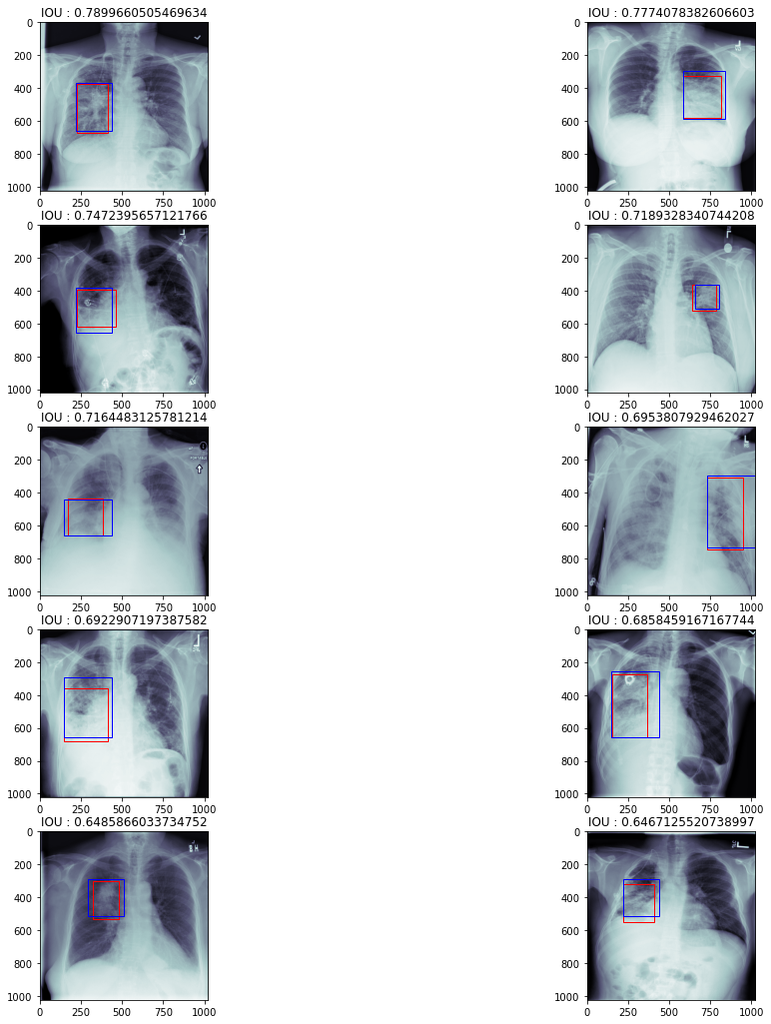

```python
top = 10
visualizePredictions(report_file_um, top)
```

Though not exactly but our model has been able to locate the region of opacities in the chest.

#### Function to plot the performance curves

```python
def plotHistory(_HISTORY_FILE) :
    """
    Arguments:
        _HISTORY_FILE: training history file name.
    """
    unetSavedHistory = np.load(_HISTORY_FILE, allow_pickle=True).item()
    unetSavedHistoryDF = pd.DataFrame(unetSavedHistory)

    #summarize history for loss
    pyplot.plot(unetSavedHistoryDF['loss'])
    pyplot.plot(unetSavedHistoryDF['val_loss'])
    pyplot.title('Model Loss')
    pyplot.ylabel('Loss')
    pyplot.xlabel('Epoch')
    pyplot.legend(['Train', 'Validation'], loc='best')
    pyplot.show()

    # summarize history for mean IOU
    pyplot.plot(unetSavedHistoryDF['mean_iou'])
    pyplot.plot(unetSavedHistoryDF['val_mean_iou'])
    pyplot.title('Model IOU')
    pyplot.ylabel('IOU')
    pyplot.xlabel('Epoch')
    pyplot.legend(['Train', 'Validation'], loc='best')
    pyplot.show()
```

```python
umobhist = np.array(history_umobile.history)
np.save("History_UNM", umobhist, allow_pickle = True)
```

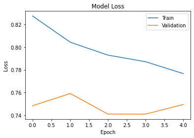

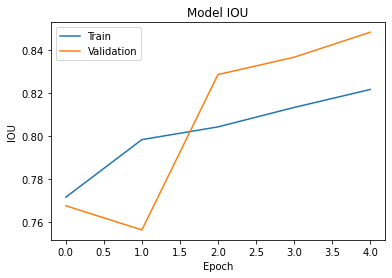

```python
history_file = './History_UNM.npy'
plotHistory(history_file)
```

```python
### UNet with Xception net
```

```python
UNet_XceptionNet_Model = create_UNetModel_Xception()
print(UNet_XceptionNet_Model.summary())
```

```
Model: "model_1"
__________________________________________________________________________________________________
Layer (type)                    Output Shape         Param #     Connected to
==================================================================================================
input_2 (InputLayer)            [(None, 224, 224, 3) 0
__________________________________________________________________________________________________
block1_conv1 (Conv2D)           (None, 111, 111, 32) 864         input_2[0][0]
__________________________________________________________________________________________________
block1_conv1_bn (BatchNormaliza (None, 111, 111, 32) 128         block1_conv1[0][0]
__________________________________________________________________________________________________
block1_conv1_act (Activation)   (None, 111, 111, 32) 0           block1_conv1_bn[0][0]
__________________________________________________________________________________________________
block1_conv2 (Conv2D)           (None, 109, 109, 64) 18432       block1_conv1_act[0][0]
__________________________________________________________________________________________________
block1_conv2_bn (BatchNormaliza (None, 109, 109, 64) 256         block1_conv2[0][0]
__________________________________________________________________________________________________
block1_conv2_act (Activation)   (None, 109, 109, 64) 0           block1_conv2_bn[0][0]
__________________________________________________________________________________________________
block2_sepconv1 (SeparableConv2 (None, 109, 109, 128 8768        block1_conv2_act[0][0]
__________________________________________________________________________________________________
block2_sepconv1_bn (BatchNormal (None, 109, 109, 128 512         block2_sepconv1[0][0]
__________________________________________________________________________________________________
block2_sepconv2_act (Activation (None, 109, 109, 128 0           block2_sepconv1_bn[0][0]
__________________________________________________________________________________________________
block2_sepconv2 (SeparableConv2 (None, 109, 109, 128 17536       block2_sepconv2_act[0][0]
__________________________________________________________________________________________________
block2_sepconv2_bn (BatchNormal (None, 109, 109, 128 512         block2_sepconv2[0][0]
__________________________________________________________________________________________________
conv2d_4 (Conv2D)               (None, 55, 55, 128)  8192        block1_conv2_act[0][0]
__________________________________________________________________________________________________
block2_pool (MaxPooling2D)      (None, 55, 55, 128)  0           block2_sepconv2_bn[0][0]
__________________________________________________________________________________________________
batch_normalization_4 (BatchNor (None, 55, 55, 128)  512         conv2d_4[0][0]
__________________________________________________________________________________________________
add_12 (Add)                    (None, 55, 55, 128)  0           block2_pool[0][0]
                                                                 batch_normalization_4[0][0]
__________________________________________________________________________________________________
block3_sepconv1_act (Activation (None, 55, 55, 128)  0           add_12[0][0]
__________________________________________________________________________________________________
block3_sepconv1 (SeparableConv2 (None, 55, 55, 256)  33920       block3_sepconv1_act[0][0]
```

[output cut: 246 more lines]

[output not shown]

```python
Thus, UNet with Xception (with some more additional layers) has a total of 20,864,985 parameters. Out of which 20,810,457 parameters are trainable and the rest are non-trainable.
```

Using Adam Optimizer and compiling the model

```python
#optimizer
adamopt_r = Adam(lr = 1e-1, beta_1 = 0.9, beta_2 = 0.999, epsilon = None, decay = 0.0, amsgrad = False)
UNet_XceptionNet_Model.compile(optimizer = adamopt_r, loss = iou_loss, metrics = [mean_iou])
```

```python
def cosine_annealing(x):
    lr = 0.001
    epochs = 10
    return lr*(np.cos(np.pi * x/epochs) + 1.) / 2

learning_rate = LearningRateScheduler(cosine_annealing)
checkpoint = ModelCheckpoint("ures-{epoch:02d}-{val_mean_iou:.2f}.h5", monitor = 'loss',
                             verbose = 1, mode = 'min', save_best_only = True,
                             save_weights_only = True)
stop = EarlyStopping(monitor = 'loss', mode = 'min', patience = 3)
```

```python
history_uXcept = UNet_XceptionNet_Model.fit_generator(generator = trainUNet, epochs = 5,
                                               validation_data = validateUNet,
                                               callbacks = [learning_rate, checkpoint, stop],
                                               shuffle = True, verbose = 1)
```

```
Epoch 00001: loss improved from inf to 0.85659, saving model to ures-01-0.49.h5

Epoch 00002: loss improved from 0.85659 to 0.83422, saving model to ures-02-0.83.h5

Epoch 00003: loss improved from 0.83422 to 0.81938, saving model to ures-03-0.60.h5

Epoch 00004: loss improved from 0.81938 to 0.81518, saving model to ures-04-0.77.h5

Epoch 00005: loss improved from 0.81518 to 0.80547, saving model to ures-05-0.85.h5
```

Going forward, we will be using the weights from "ures-05-0.85.h5".

```python
UNet_XceptionNet_Model.load_weights('./ures-05-0.85.h5')
```

Predicting on the test set

```python
y_test, y_predicted = predictBatches(test_mergedata, test_imageIdpaths, UNet_XceptionNet_Model)
```

```
Number of Test Samples: 4920
Predicting Batches Prediction Complete!
```

```python
report_file_uX = pd.read_csv('./submission.csv')
showConfusionMatrix(report_file_uX)
```

```
Predictions in terms of IOU :

Confusion Matrix:
 [[4214    0]
 [ 597  143]]

Classification Report:
               precision    recall  f1-score   support

         0.0       0.88      1.00      0.93      4214
         1.0       1.00      0.19      0.32       740

    accuracy                           0.88      4954
   macro avg       0.94      0.60      0.63      4954
weighted avg       0.89      0.88      0.84      4954
```

Visualizing the Prediction

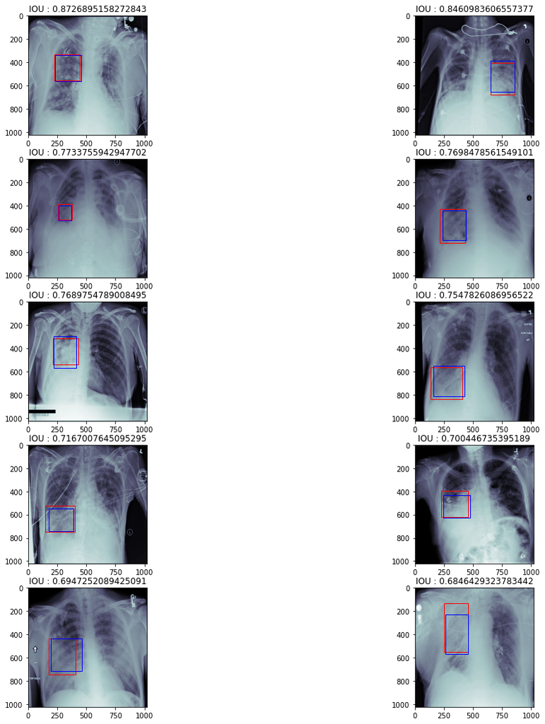

```python
top = 10
visualizePredictions(report_file_uX, top)
```

Though not exactly but our model has been able to locate the region of opacities in the chest.

```python
uXcepthist = np.array(history_uXcept.history)
np.save("History_UX", ureshist, allow_pickle = True)
```

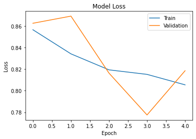

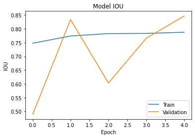

```python
history_file = './History_UX.npy'
plotHistory(history_file)
```

### summary of the model implementation

1.In our project we started with exploring the given dataset and we find how the various attributes (obtained from both the files and images) are spread across the entire dataset 2.in our project work we have implemented 3 base model Res-net mobile net and the Xception nets 3.in the inpy file we have impleted with 2 base model mobile net and Xception net model and the corresponding model accuracy has been capture as show in the above 4.Here we trained the model 5 epoch that is giving us better results and output as show in above 5.in this work we have faced two challenges : First to write a function that can load the entire dataset at once and secondly Model Selection and model selection also played an major impact for this binary classification whether the person is effected with Pneumonia or non Pneumonia. 6.Still we can improve the model by increasing the number epoch and also by performing the model tuning.